# Getting Started Fall 2025

You will be working together to get up to speed on the “10 Essentials” found here: https://edav.info/learning_R.html

### 1. Meet your group

Who are the members of your group? Tell me a bit about everyone. Where and when did you meet to work on this assignment? Include a group selfie or (Zoom screenshot).

- We met in the DSI lounge and zoom meeting!
- Emily Ramond: Undergrad from UCSD in data science, lives in Midtown, worked for three years following undergrad.
- Ching-Heng Huang: Come from Taiwan, majoring in Quantitative Finance, worked for three years at EY.
- Chih-Yuan Chang: Also from Taiwan, majoring in psychology and environmental engineering.
- David Dai: Come from Beijing, majoring in data science at Columbia, undergraduate in Math and DS from NYU.

### 2. Install R and RStudio

If they’re already installed, update to the latest versions. Run this code:

```r
R.version$version.string
```

```
[1] "R version 4.5.1 (2025-06-13)"
```

Run this line *in the Console* and copy and paste the results below.

`rstudioapi::getVersion()`  
[1] ‘2025.5.1.513’

### 3. Get comfortable with RStudio.

Install the **tidyverse** collection of packages as well as **devtools**. Run this code:

```r
# install.packages("tidyverse")
# install.packages("devtools")
find.package("tidyverse")
```

```
[1] "/Users/joshuahuang1999/Library/R/arm64/4.5/library/tidyverse"
```

```r
find.package("devtools")
```

```
[1] "/Users/joshuahuang1999/Library/R/arm64/4.5/library/devtools"
```

### 4. Nuts and Bolts

Get comfortable with vectors and data frames. Create a data frame called `df` below with columns that are each a different data type: integer, numeric, character, logical, and factor. Run the code:

```r
# Add your data frame here
# integer
age <- as.integer(c(24, 25, 26, 25))
# numeric
age_d <- c(24.7, 25.1, 26.4, 25.2)
# character
name <- c("Emily","David","Cheng-Heng", "Chih-Yuan")
# logical
DSI <- c(TRUE, TRUE, TRUE, TRUE)
# factor
bday = factor(c("Feb","March","May","July"))
# Create data frame df
df = data.frame(Name=name, Age=age, Age_approx=age_d,DSI_student=DSI, bday=bday)
df
```

```
        Name Age Age_approx DSI_student  bday
1      Emily  24       24.7        TRUE   Feb
2      David  25       25.1        TRUE March
3 Cheng-Heng  26       26.4        TRUE   May
4  Chih-Yuan  25       25.2        TRUE  July
```

### 5. Make some graphs with ggplot2

Use data from the *bad_drivers* dataset in the **fivethirtyeight** package.

No rules… have fun!

```r
#install.packages("fivethirtyeight")
#install.packages("dplyr")
#install.packages("ggplot2")
```

```r
# Import packages
library(ggplot2)
library(stats)
library(stringr)
suppressMessages(library(fivethirtyeight))
suppressMessages(library(dplyr))
```

```r
# Inspect data
data <- as.data.frame(bad_drivers)
head(data)
```

```
       state num_drivers perc_speeding perc_alcohol perc_not_distracted
1    Alabama        18.8            39           30                  96
2     Alaska        18.1            41           25                  90
3    Arizona        18.6            35           28                  84
4   Arkansas        22.4            18           26                  94
5 California        12.0            35           28                  91
6   Colorado        13.6            37           28                  79
  perc_no_previous insurance_premiums losses
1               80             784.55 145.08
2               94            1053.48 133.93
3               96             899.47 110.35
4               95             827.34 142.39
5               89             878.41 165.63
6               95             835.50 139.91
```

#### Make some plots with bad_drivers

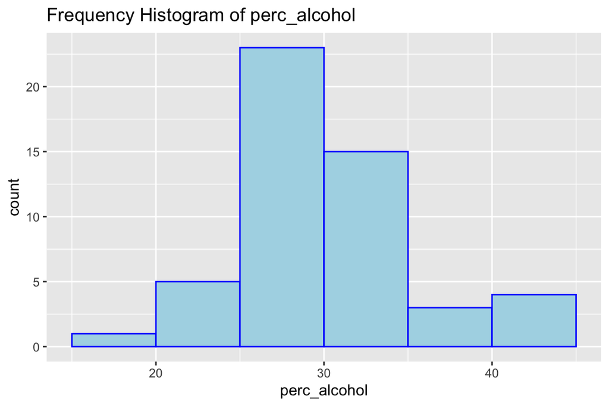

```r
# 1. Frequency Histogram of perc_alcohol
ggplot(data,aes(perc_alcohol)) +
  ggtitle("Frequency Histogram of perc_alcohol") +
  geom_histogram(color = "blue", fill = "lightBlue", binwidth = 5, center = 52.5)
```

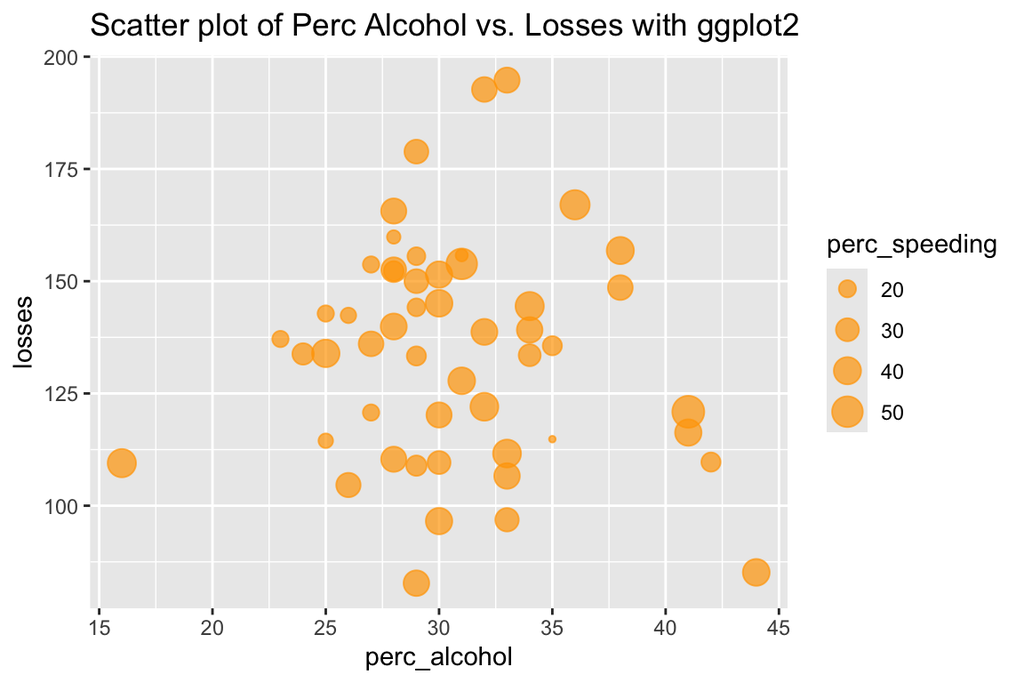

```r
# 2. Scatter plot of Perc Alcohol vs. Losses
ggplot(data, aes(perc_alcohol, losses, size = perc_speeding)) +
  geom_point(colour = 'orange', alpha = 0.7) +
  ggtitle("Scatter plot of Perc Alcohol vs. Losses with ggplot2")
```

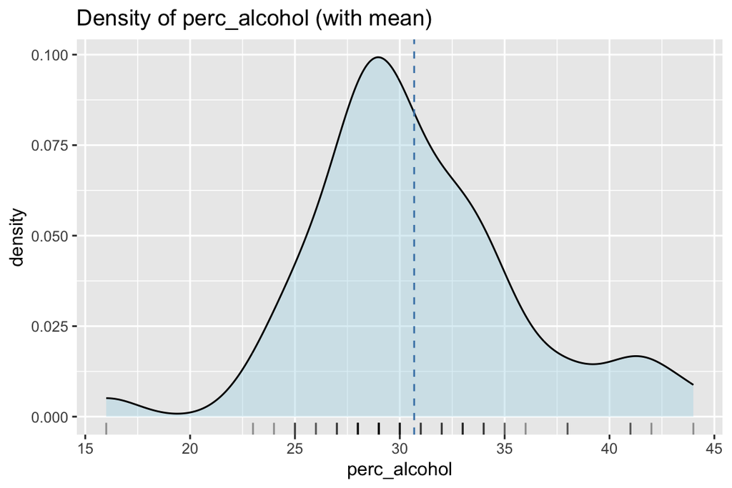

```r
ggplot(data, aes(perc_alcohol)) +
  geom_density(fill = "lightblue", alpha = 0.4) +
  geom_rug(alpha = 0.4) +
  geom_vline(aes(xintercept = mean(perc_alcohol, na.rm = TRUE)),
             linetype = 2, color = "steelblue") +
  ggtitle("Density of perc_alcohol (with mean)")
```

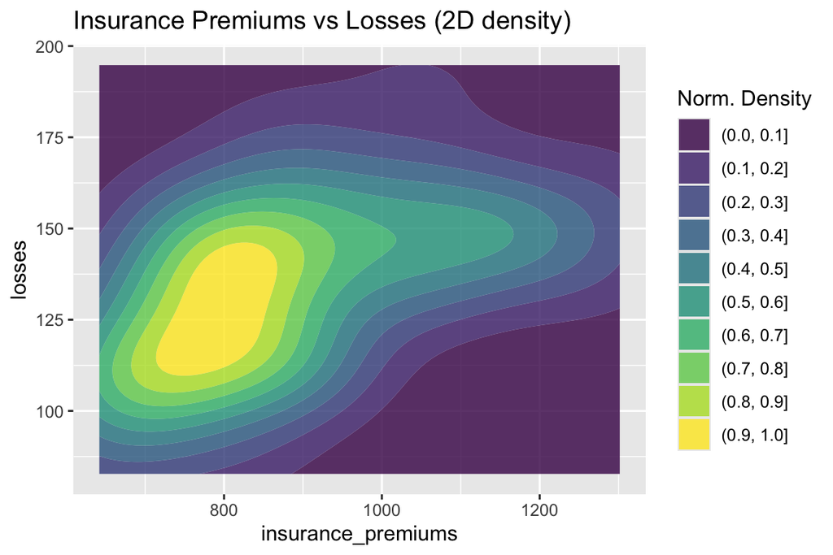

```r
ggplot(data, aes(insurance_premiums, losses)) +
  stat_density_2d_filled(contour_var = "ndensity", alpha = 0.8) +
  ggtitle("Insurance Premiums vs Losses (2D density)") +
  labs(fill = "Norm. Density")
```

[figure not shown]

```r
# 3. Scatter Plot of Insurance Premiums vs Losses

# Define a linear fit layer
linearfit <- geom_smooth(
  method = "lm",
  se = FALSE,
  colour = alpha("lightblue", 0.9),
  linewidth = 2
)

# Perform a correlation test between insurance_premiums and losses,
# then store the correlation coefficient and p-value
corr_test <- cor.test(data$insurance_premiums, data$losses)
corr <- corr_test$estimate
p <- corr_test$p.value

# Create a scatter plot
ggplot(data, aes(insurance_premiums, losses)) +
  geom_point() +
  ggtitle("Insurance Premiums vs Losses with ggplot2") +
  linearfit +
  annotate("text", x = 730, y = 200,
           label = sprintf("r = %.3f, p = %.3e", corr, p))
```

### 6. Practice using the main **dplyr** verbs for data transformation.

Try out the following `filter()`, `select()`, `mutate()`, `arrange()`, `group_by` and `summarize()` using data from the *foul_balls* dataset in the **fivethirtyeight** package.

```r
# Inspect data
foul_balls_df <- as.data.frame(foul_balls)
head(foul_balls_df)
```

```
                              matchup  game_date type_of_hit exit_velocity
1 Seattle Mariners vs Minnesota Twins 2019-05-18      Ground            NA
2 Seattle Mariners vs Minnesota Twins 2019-05-18         Fly            NA
3 Seattle Mariners vs Minnesota Twins 2019-05-18         Fly          56.9
4 Seattle Mariners vs Minnesota Twins 2019-05-18         Fly          78.8
5 Seattle Mariners vs Minnesota Twins 2019-05-18         Fly            NA
6 Seattle Mariners vs Minnesota Twins 2019-05-18      Ground            NA
  predicted_zone camera_zone used_zone
1              1           1         1
2              4        <NA>         4
3              4        <NA>         4
4              1           1         1
5              2        <NA>         2
6              1           1         1
```

```r
# Filter: Filter where type_of_hit == Fly
head(filter(foul_balls_df, type_of_hit == "Fly"))
```

```
                              matchup  game_date type_of_hit exit_velocity
1 Seattle Mariners vs Minnesota Twins 2019-05-18         Fly            NA
2 Seattle Mariners vs Minnesota Twins 2019-05-18         Fly          56.9
3 Seattle Mariners vs Minnesota Twins 2019-05-18         Fly          78.8
4 Seattle Mariners vs Minnesota Twins 2019-05-18         Fly            NA
5 Seattle Mariners vs Minnesota Twins 2019-05-18         Fly          74.8
6 Seattle Mariners vs Minnesota Twins 2019-05-18         Fly          70.7
  predicted_zone camera_zone used_zone
1              4        <NA>         4
2              4        <NA>         4
3              1           1         1
4              2        <NA>         2
5              2        <NA>         2
6              4        <NA>         4
```

```r
# Filter: Filter where data starts with Seattle (where emily lived past 3 years)
head(filter(foul_balls_df, str_detect(matchup, "^Seattle")))
```

```
                              matchup  game_date type_of_hit exit_velocity
1 Seattle Mariners vs Minnesota Twins 2019-05-18      Ground            NA
2 Seattle Mariners vs Minnesota Twins 2019-05-18         Fly            NA
3 Seattle Mariners vs Minnesota Twins 2019-05-18         Fly          56.9
4 Seattle Mariners vs Minnesota Twins 2019-05-18         Fly          78.8
5 Seattle Mariners vs Minnesota Twins 2019-05-18         Fly            NA
6 Seattle Mariners vs Minnesota Twins 2019-05-18      Ground            NA
  predicted_zone camera_zone used_zone
1              1           1         1
2              4        <NA>         4
3              4        <NA>         4
4              1           1         1
5              2        <NA>         2
6              1           1         1
```

```r
# Select: Select columns from foul_balls_df where column names start with "match"
head(select(foul_balls_df, starts_with("match")))
```

```
                              matchup
1 Seattle Mariners vs Minnesota Twins
2 Seattle Mariners vs Minnesota Twins
3 Seattle Mariners vs Minnesota Twins
4 Seattle Mariners vs Minnesota Twins
5 Seattle Mariners vs Minnesota Twins
6 Seattle Mariners vs Minnesota Twins
```

```r
# Mutate: Create perc_velocity = exit_velocity / 100
head(mutate(foul_balls_df, perc_velocity = exit_velocity /100))
```

```
                              matchup  game_date type_of_hit exit_velocity
1 Seattle Mariners vs Minnesota Twins 2019-05-18      Ground            NA
2 Seattle Mariners vs Minnesota Twins 2019-05-18         Fly            NA
3 Seattle Mariners vs Minnesota Twins 2019-05-18         Fly          56.9
4 Seattle Mariners vs Minnesota Twins 2019-05-18         Fly          78.8
5 Seattle Mariners vs Minnesota Twins 2019-05-18         Fly            NA
6 Seattle Mariners vs Minnesota Twins 2019-05-18      Ground            NA
  predicted_zone camera_zone used_zone perc_velocity
1              1           1         1            NA
2              4        <NA>         4            NA
3              4        <NA>         4         0.569
4              1           1         1         0.788
5              2        <NA>         2            NA
6              1           1         1            NA
```

```r
# Arrange: Sort foul_balls_df by type_of_hit (batter hits self lollol)
head(arrange(foul_balls_df, type_of_hit))
```

```
                                  matchup  game_date      type_of_hit
1     Seattle Mariners vs Minnesota Twins 2019-05-18 Batter hits self
2     Seattle Mariners vs Minnesota Twins 2019-05-18 Batter hits self
3     Seattle Mariners vs Minnesota Twins 2019-05-18 Batter hits self
4    Baltimore Orioles vs Minnesota Twins 2019-04-20 Batter hits self
5 Pittsburgh Pirates vs Milwaukee Brewers 2019-06-01 Batter hits self
6      Milwaukee Brewers vs New York Mets 2019-05-04 Batter hits self
  exit_velocity predicted_zone camera_zone used_zone
1          69.9              1           1         1
2            NA              1           1         1
3            NA              1           1         1
4          66.3              1           1         1
5          68.3              1           1         1
6            NA              1           1         1
```

```r
# Groupby: Compute the mean of exit_velocity by each type_of_hit (ignoring NAs)
foul_balls_df |>
  dplyr::group_by(type_of_hit) |>
  dplyr::summarise(mean_velocity = mean(exit_velocity, na.rm = TRUE))
```

```
# A tibble: 5 × 2
  type_of_hit      mean_velocity
  <fct>                    <dbl>
1 Batter hits self          69.4
2 Fly                       76.7
3 Ground                    74.4
4 Line                      82.2
5 Pop Up                    74.3
```

```r
# Summarize: Compute total exit_velocity by type_of_hit (ignoring NAs)
summarize(foul_balls_df, sum_velocity = sum(exit_velocity,na.rm = TRUE), .by=type_of_hit)
```

```
       type_of_hit sum_velocity
1           Ground       8705.1
2              Fly      28392.7
3             Line       3451.5
4 Batter hits self        346.9
5           Pop Up       3416.6
```

### 7. Summary

Describe any questions / issues that came up and the solutions.

1. We had some issues with how to read in data and transform data types to the correct format. We used the documentation for R to discover how to do this.
2. For ggplot2 plotting, we referred to the **ggplot2** online book (https://ggplot2-book.org/) to check common syntax patterns. All code was run locally and cross-checked with official documentation.

Describe AI use, including screenshots, model names/versions as relevant. What helped? What didn’t?

1. What model?
- When we searched on Google, Gemini(2.5 Flash) appeared as a helpful tool, and we used it to collect guidance on R functions.
2. What helped?
- It significantly reduced the amount of time we would have otherwise spent searching extensive documentation and data, allowing us to understand the purpose of each function more efficiently.
3. What didn’t?
- However, Gemini sometimes did not provide concrete usage examples, which caused some confusion and required us to consult additional resources.